# GEOG215 Final Project

Samuel Metcalf

2025-04-26

# Exploratory Spatial Data Analysis

#### by Sam Metcalf - 4/26/25

## Title

*The Lingering Impacts of Redlining on Residential Segregation in Durham, North Carolina*

### Topic

Since the mid-twentieth century, there has been no greater contributor to personal wealth in the United States–and no personal achievement more synonymous with the American Dream–than homeownership, accounting for more than half of the wealth of U.S. households across all racial groups (Kochhar and Moslimani, 2023). Beginning in 1934, the Federal Housing Administration (a program of the New Deal) made the promise of homeownership a reality for generations of Americans. However, this promise was not afforded to everyone (Fritz, 2025). The Federal Housing Administration relied heavily on maps produced by the Home Owner’s Loan Corporation–so-called “redlining” maps–to base their investment and mortgage activity. HOLC’s classification of neighborhoods was heavily influenced by the presence of minority ethnic groups, and particularly African-Americans (Gross, 2017). In practice, this meant that residents predominantly African-American neighborhoods (and even racially integrated neighborhoods) were deprived of this pathway to personal wealth, contributing to the persistent financial disparity between Whites and African-Americans.

This project seeks to explore the historical impact of redlining on current neighborhood racial patterns in Durham, North Carolina. Using block-level data from the 2000 and 2020 Decennial Censuses, this project will determine the extent to which redlining grade boundaries overlapped with neighborhood segregation patterns, and whether this overlap has changed over time amid shifting demographic trends in Durham. I hypothesize that redlining was a strong factor in reinforcing neighborhood segregation, even into the twenty-first century, but that the neighborhood segregation of Durham lessened to some degree between 2000 and 2020.

### Data

```r
library(tidyverse)
library(tmap)
library(tidycensus)
library(sf)
library(sfdep)
library(spdep)
options(tigris_use_cache = TRUE)
```

```r
durhamCounty2000 <- get_decennial(
  geography = "block",
  variables = c( p_total = "P003001",
                 p_white = "P003003",
                 p_black = "P003004",
                 p_ntvAm = "P003005",
                 p_asian = "P003006",
                 p_ntvHn = "P003007",
                 p_other = "P003008",
                 p_twoOM = "P003009"
  ),
  state = "NC",
  county = 063,
  year = 2000,
  output = "wide",
  geometry = TRUE
)
```

```
## Using Census Summary File 1
```

```r
durhamCounty2020 <- get_decennial(
  geography = "block",
  variables = c(p_total = "P3_001N",
                p_white = "P3_003N",
                p_black = "P3_004N",
                p_ntvAm = "P3_005N",
                p_asian = "P3_006N",
                p_ntvHn = "P3_007N",
                p_other = "P3_008N",
                p_twoOM = "P3_009N"
  ),

  state = "NC",
  county = 063,
  year = 2020,
  output = "wide",
  geometry = TRUE
)
```

```
## Using the PL 94-171 Redistricting Data Summary File
```

```
## Note: 2020 decennial Census data use differential privacy, a technique that
## introduces errors into data to preserve respondent confidentiality.
## ℹ Small counts should be interpreted with caution.
## ℹ See https://www.census.gov/library/fact-sheets/2021/protecting-the-confidentiality-of-the-2020-census-redistricting-data.html for additional guidance.
```

This script obtains the number of people within each designated racial group–White, Black, Native American, Asian, Native Hawaiian/Pacific Islander, plus categories for those responding as “Other” or “Two or more”–for each census block in Durham County, North Carolina, along with tract geometries.

Importantly, this script does not include variables to count residents identifying as Hispanic or Latino, because those are ethnic groups that are not mutually exclusive with self-identified race. Further research into this topic should make an effort to address this shortfall, but given time constraints I was unable to properly account for this complication.

```r
tmp_geojson <- tempfile(fileext = ".geojson")
download.file(
  "https://dsl.richmond.edu/panorama/redlining/static/citiesData/NCDurham1937/geojson.json",
  tmp_geojson
)

durhamRedlining <- read_sf(tmp_geojson)
rm(tmp_geojson)
```

To classify tracts into different redlining grades between years, this analysis used a vectorized geojson dataset containing redlining boundaries of Durham, North Carolina from the University of Richmond’s Mapping Inequality project.

### Methods

I began by performing an inner spatial join of the redlining classifications to the datasets containing demographics of Durham census blocks from 2000 and 2020. The census datasets and the redlining dataset used different coordinate systems, so I first converted all three into the North Carolina State Plane Coordinate System (EPSG 32119).

```r
# NC state plane
durhamCounty2000 <- st_transform(durhamCounty2000, 32119)
durhamCounty2020 <- st_transform(durhamCounty2020, 32119)
durhamRedlining <- st_transform(durhamRedlining, 32119)
```

```r
combinedData2000 <- durhamCounty2000 |>
  st_join(
    durhamRedlining,
    join = st_intersects,
    left = FALSE,
    largest = TRUE
  )

combinedData2020 <- durhamCounty2020 |>
  st_join(
    durhamRedlining,
    join = st_intersects,
    left = FALSE,
    largest = TRUE
  )
```

```r
combinedData2000 <- combinedData2000 |>
  mutate( # proportions
    propWhite = p_white / p_total,
    propBlack = p_black / p_total,
    propNtvAm = p_ntvAm / p_total,
    propAsian = p_asian / p_total,
    propNtvHn = p_ntvHn / p_total,
    propOther = p_other / p_total,
    propTwoOM = p_twoOM / p_total
    )
combinedData2020 <- combinedData2020 |>
  mutate( # proportions
    propWhite = p_white / p_total,
    propBlack = p_black / p_total,
    propNtvAm = p_ntvAm / p_total,
    propAsian = p_asian / p_total,
    propNtvHn = p_ntvHn / p_total,
    propOther = p_other / p_total,
    propTwoOM = p_twoOM / p_total
    )
```

```r
# create new column for diversity index calc

combinedData2020 <- combinedData2020 |>
  mutate(diversity = 1 -
           ((propWhite)^2 +
              (propBlack)^2 +
              (propNtvAm)^2 +
              (propAsian)^2 +
              (propNtvHn)^2 +
              (propOther)^2 +
              (propTwoOM)^2))

combinedData2000 <- combinedData2000 |>
  mutate(diversity = 1 -
           ((propWhite)^2 +
              (propBlack)^2 +
              (propNtvAm)^2 +
              (propAsian)^2 +
              (propNtvHn)^2 +
              (propOther)^2 +
              (propTwoOM)^2))
```

Finally, I created a column to classify the majority/plurality racial group within each block–for example, a block with 60% white residents would return “White, Majority”.

```r
# create new columns to define majority/plurality race in each block

combinedData2020 <- combinedData2020 |>
  mutate(blockType = case_when(
    #majorities
    propWhite > 0.5 ~ "White, Majority",
    propBlack > 0.5 ~ "Black, Majority",
    propNtvAm > 0.5 ~ "Native American, Majority",
    propAsian > 0.5 ~ "Asian, Majority",
    propNtvHn > 0.5 ~ "Native Hawaiian or PI, Majority",
    #pluralities
    p_white > p_black & p_white > p_ntvAm & p_white > p_asian & p_white > p_ntvHn ~ "White, Plurality",
    p_black > p_white & p_black > p_ntvAm & p_black > p_asian & p_black > p_ntvHn ~ "Black, Plurality",
    p_ntvAm > p_white & p_ntvAm > p_black & p_ntvAm > p_asian & p_ntvAm > p_ntvHn ~ "Native American, Plurality",
    p_asian > p_white & p_asian > p_black & p_asian > p_ntvAm & p_asian > p_ntvHn ~ "Asian, Plurality",
    p_ntvHn > p_white & p_ntvHn > p_black & p_ntvHn > p_ntvAm & p_ntvHn > p_asian ~ "Native Hawaiian or PI, Plurality",
    #no pop
    p_total == 0 ~ "Industrial / Sparsely Populated",
    #other
    .default = "Other, Other"
  )) |>
  mutate(predomRace = str_split_i(blockType, ", ", 1)) |>
  mutate(MajOrPlu = str_split_i(blockType, ", ", 2))

combinedData2000 <- combinedData2000 |>
  mutate(blockType = case_when(
    #majorities
    propWhite > 0.5 ~ "White, Majority",
    propBlack > 0.5 ~ "Black, Majority",
    propNtvAm > 0.5 ~ "Native American, Majority",
    propAsian > 0.5 ~ "Asian, Majority",
    propNtvHn > 0.5 ~ "Native Hawaiian or PI, Majority",
    #pluralities
    p_white > p_black & p_white > p_ntvAm & p_white > p_asian & p_white > p_ntvHn ~ "White, Plurality",
    p_black > p_white & p_black > p_ntvAm & p_black > p_asian & p_black > p_ntvHn ~ "Black, Plurality",
    p_ntvAm > p_white & p_ntvAm > p_black & p_ntvAm > p_asian & p_ntvAm > p_ntvHn ~ "Native American, Plurality",
    p_asian > p_white & p_asian > p_black & p_asian > p_ntvAm & p_asian > p_ntvHn ~ "Asian, Plurality",
    p_ntvHn > p_white & p_ntvHn > p_black & p_ntvHn > p_ntvAm & p_ntvHn > p_asian ~ "Native Hawaiian or PI, Plurality",
    #no pop
    p_total == 0 ~ "Industrial / Sparsely Populated",
    #other
    .default = "Other, Other"
  )) |>
  mutate(predomRace = str_split_i(blockType, ", ", 1)) |>
  mutate(MajOrPlu = str_split_i(blockType, ", ", 2))
```

Finally, I cleaned the data to update the grade classification to account for industrial/sparsely populated tracts (the original redlining dataset marked those sections with a null value in the grade column), and added a column to designate the year for each row of block data so that I could produce facet maps later using the `tm_facet()` function.

```r
# data cleaning; fixing no data in census block grade; combining

combinedData2020 <- combinedData2020 |>
  mutate(grade = ifelse(is.na(grade), "Industrial / Sparsely Populated", grade),
         year = 2020)

combinedData2000 <- combinedData2000 |>
  mutate(grade = ifelse(is.na(grade), "Industrial / Sparsely Populated", grade),
         year = 2000)

combinedDataAll <- rbind(combinedData2020, combinedData2000)
```

### Exploratory Spatial Data Analysis

For this portion of the assignment, I explored the spatial distribution of the White population at the block level throughout Durham County, North Carolina, in the year 2020. The data for this analysis comes from the 2020 Census via the Census API, utilizing a variable that counts the number of respondents that self-identify as White for each census tract throughout Durham County.

#### Descriptive Statistics

```r
mean(durhamCounty2020$p_white)
```

```
## [1] 27.02045
```

```r
median(durhamCounty2020$p_white)
```

```
## [1] 10
```

```r
sd(durhamCounty2020$p_white)
```

```
## [1] 54.67889
```

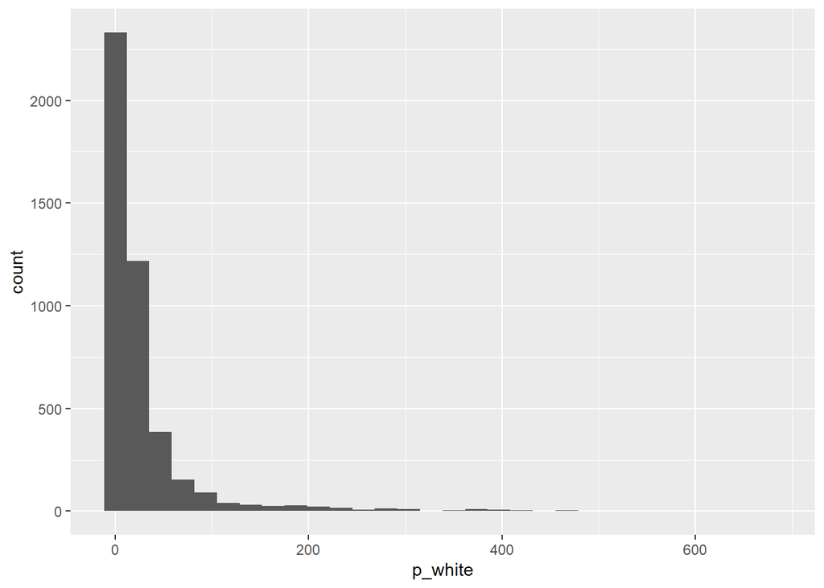

```r
ggplot(durhamCounty2020, aes(p_white)) +
  geom_histogram()
```

The wide discrepancy in mean and median and the extremely large standard deviation relative to each of these values suggest that the white population by block in Durham County is heavily skewed. Indeed, the histogram indicates that the data is heavily right-skewed.

#### Initial Statistics

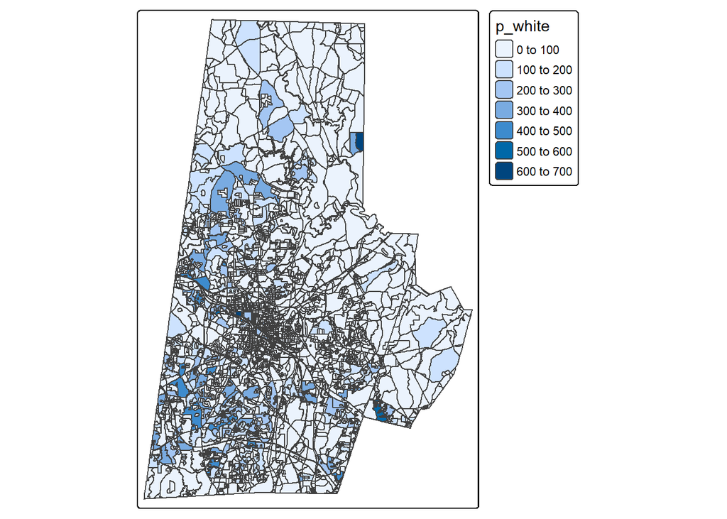

```r
tm_shape(durhamCounty2020)+
  tm_polygons("p_white")
```

This map of the total white population of Durham by block suggests that there are more significant concentrations of white population in the suburban areas of the city of Durham. Because census blocks are not a uniform population size, this map closely resembles a map of total population per block. A better analysis would normalize the white population values to the total population values:

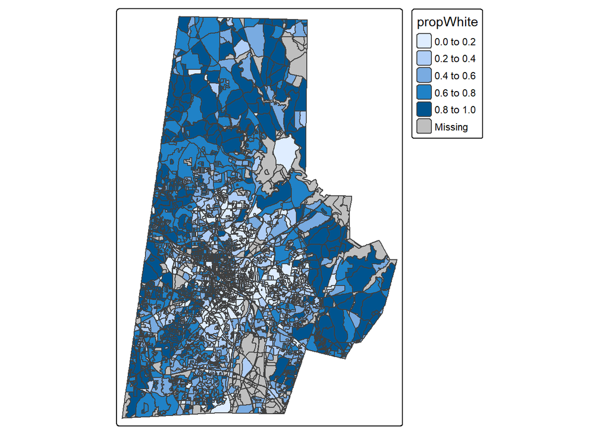

```r
durhamCounty2020 |>
  mutate(propWhite = p_white / p_total) |>
  tm_shape()+
  tm_polygons("propWhite")
```

Indeed, this normalized map illuminates how the white population in Durham County is concentrated in the western suburbs of the city of Durham and the furthest eastern and northern blocks in the county.

#### Spatial Statistics

##### Mean Center

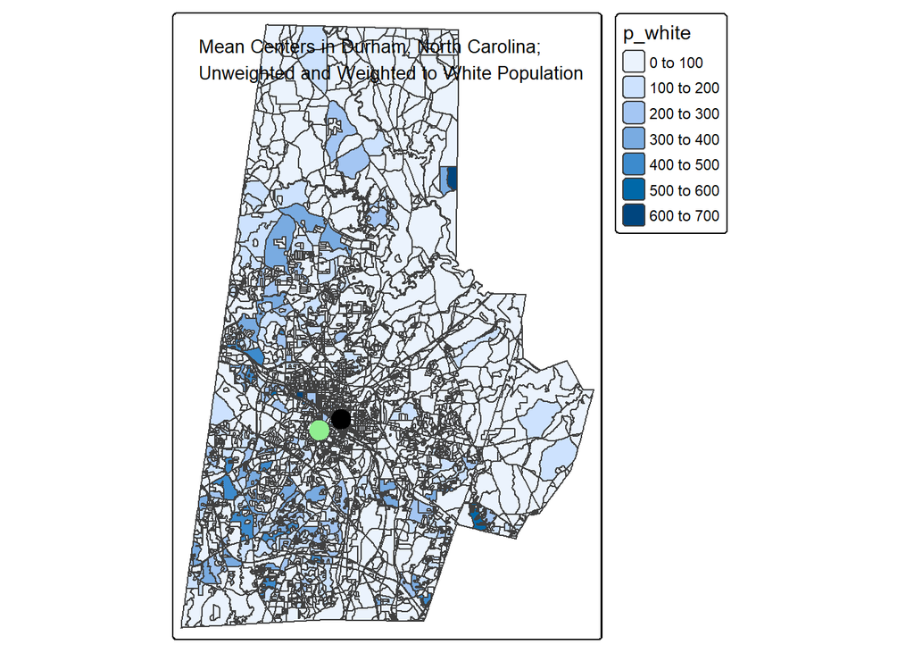

```r
#defining function
meanCenter <- function(layer, weights=NULL) {
  #converting data into points
  points <- st_centroid(layer)

  if (is.null(weights)) {
    weights <- rep(c(1),times=nrow(layer))
  }

  #calculating x & y coords
  mc_x <- weighted.mean(st_coordinates(points$geometry)[,1], weights)
  mc_y <- weighted.mean(st_coordinates(points$geometry)[,2], weights)

  #creating a point
  mean_center <- st_sfc(st_point(c(mc_x, mc_y)))

  #adding a projection
  mean_center <- st_set_crs(mean_center, st_crs(layer))

  #return object
  mean_center
}

#calculating mean center and weighted mean center
meanCenterDurham <- meanCenter(durhamCounty2020)
meanCenterDurhamWeighted <- meanCenter(durhamCounty2020, durhamCounty2020$p_white)

#mapping points
map1 <- tm_shape(meanCenterDurham) + tm_dots(fill="black", size=1)
map2 <- tm_shape(meanCenterDurhamWeighted) + tm_dots(fill="lightgreen", size=1)
map3 <- tm_shape(durhamCounty2020) + tm_polygons("p_white")
map3 + map1 + map2 + tm_layout(title="Mean Centers in Durham, North Carolina;\nUnweighted and Weighted to White Population")
```

##### Standard Circle

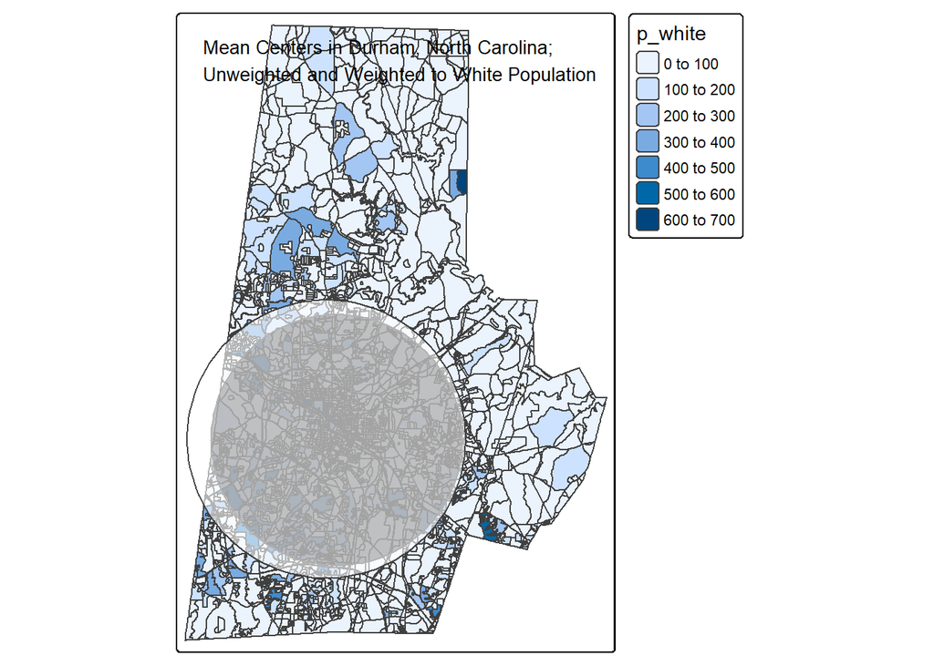

```r
#defining function
stdCircle <- function(layer, weights=NULL) {
  #converting data into points
  points <- st_centroid(layer)

  if (is.null(weights)) {
    weights <- rep(c(1),times=nrow(layer))
  }

  #calculating x & y coords
  mc_x <- weighted.mean(st_coordinates(points$geometry)[,1], weights)
  mc_y <- weighted.mean(st_coordinates(points$geometry)[,2], weights)
  mean_center <- meanCenter(layer, weights)

  #calculating standard distance
  sd <- sqrt((sum(weights *
                    (st_coordinates(points$geometry)[,1] - mc_x)^2)
                    / sum(weights))+
               (sum(weights *
                    (st_coordinates(points$geometry)[,2] - mc_y)^2)
                    / sum(weights)))

  #buffer mean center with standard distance
  std_circle <- st_buffer(mean_center, sd)

  #return std circle
  std_circle
}

stdCircleTotal <- stdCircle(durhamCounty2020, durhamCounty2020$p_total)
stdCircleWhite <- stdCircle(durhamCounty2020, durhamCounty2020$p_white)

map1 <- tm_shape(stdCircleTotal) + tm_polygons("black", alpha=.6)
map2 <- tm_shape(stdCircleWhite) + tm_polygons("white", alpha=.6)
map3 <- tm_shape(durhamCounty2020) + tm_polygons("p_white")
map3 + map1 + map2 + tm_layout(title="Mean Centers in Durham, North Carolina;\nUnweighted and Weighted to White Population")
```

Because the standard circle is slightly larger for the white population than the population at-large, it can be determined that the white population is slightly more spatially dispersed than the average across racial groups.

#### Hot-Spot Analysis

```r
#creating neighborhoods and weights
nbhds <- st_contiguity(durhamCounty2020, queen=TRUE)
wts <- st_weights(nbhds, style="W")

#calculating moran's I
moran <- global_moran(durhamCounty2020$p_white, nbhds, wts)
moran
```

```
## $I
## [1] 0.1731262
##
## $K
## [1] 31.83677
```

This result for the Moran’s I calculation demonstrates that the data is slightly clustered, although it would likely exhibit a higher clustering value if the data was normalized to total population.

```r
nb_durham <- poly2nb(durhamCounty2020, queen = TRUE)
durham_binary <- nb2listw(nb_durham, style="B")

globalG.test(durhamCounty2020$p_white, durham_binary)
```

```
##
##  Getis-Ord global G statistic
##
## data:  durhamCounty2020$p_white
## weights: durham_binary
##
## standard deviate = 44.671, p-value < 2.2e-16
## alternative hypothesis: greater
## sample estimates:
## Global G statistic        Expectation           Variance
##       4.475488e-03       1.433868e-03       4.636172e-09
```

```r
durham_nbs <- durhamCounty2020 |>
  mutate(
    nb = st_contiguity(geometry),
    wt = st_weights(nb),
    lag = st_lag(p_white, nb, wt)
  )

durham_hot_spots <- durham_nbs |>
  mutate(
    Gi = local_g_perm(p_white, nb, wt, nsim=999)
  ) |>
  unnest(Gi)
```

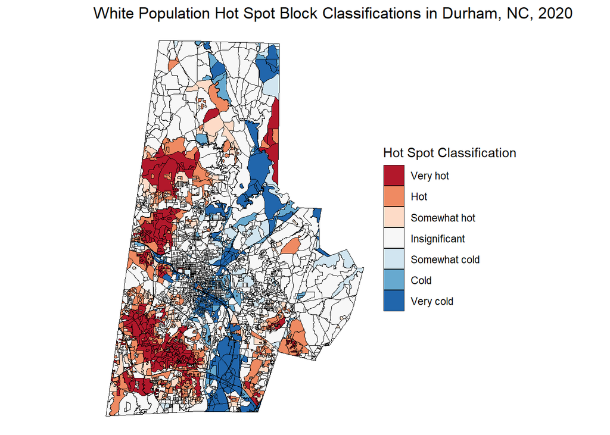

```r
durham_hot_spots |>
  # with the columns 'gi' and 'p_folded_sim"
  # 'p_folded_sim' is the p-value of a folded permutation test
  select(gi, p_folded_sim) |>
  mutate(
    # Add a new column called "classification"
    classification = case_when(
      # Classify based on the following criteria:
      gi > 0 & p_folded_sim <= 0.01 ~ "Very hot",
      gi > 0 & p_folded_sim <= 0.05 ~ "Hot",
      gi > 0 & p_folded_sim <= 0.1 ~ "Somewhat hot",
      gi < 0 & p_folded_sim <= 0.01 ~ "Very cold",
      gi < 0 & p_folded_sim <= 0.05 ~ "Cold",
      gi < 0 & p_folded_sim <= 0.1 ~ "Somewhat cold",
      TRUE ~ "Insignificant"
    ),
    # Convert 'classification' into a factor for easier plotting
    classification = factor(
      classification,
      levels = c("Very hot", "Hot", "Somewhat hot",
                 "Insignificant",
                 "Somewhat cold", "Cold", "Very cold")
    )
  ) |>
  ggplot(aes(fill = classification)) +
  geom_sf(color = "black", lwd = 0.1) +
  scale_fill_brewer(type = "div", palette = 5) +
  theme_void() +
  labs(
    fill = "Hot Spot Classification",
    title = "White Population Hot Spot Block Classifications in Durham, NC, 2020"
  )
```

### Results

#### Plots

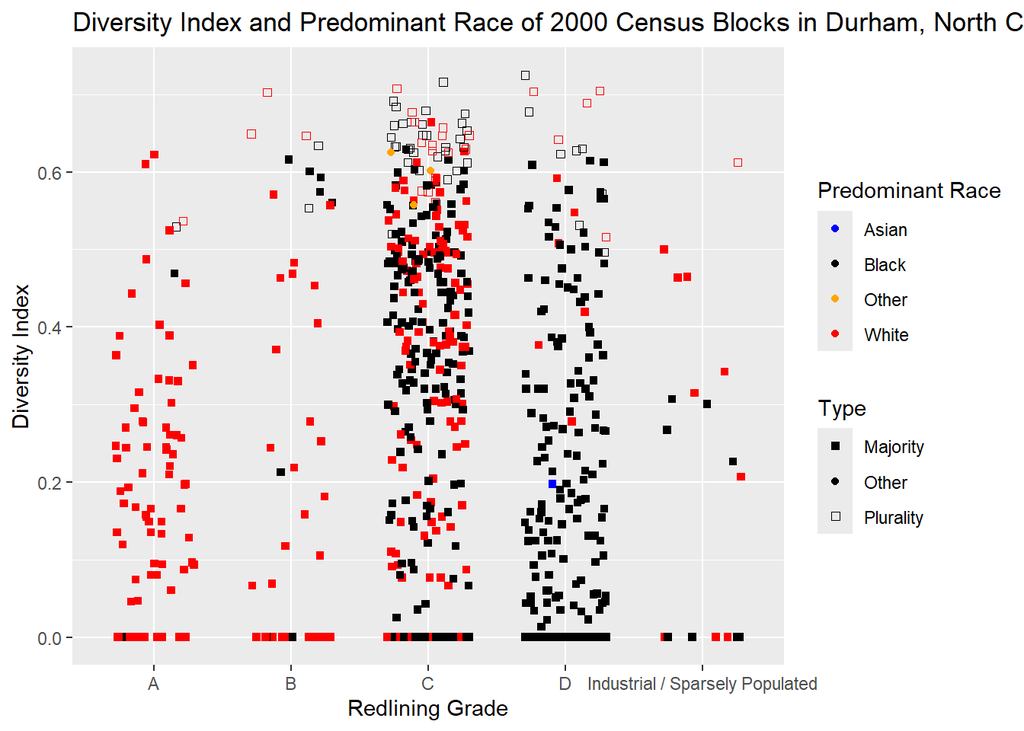

```r
combinedData2000 |>
  filter(blockType != "Industrial / Sparsely Populated") |>
  ggplot(aes(grade, diversity)) +
    geom_jitter(width = 0.3, aes(color = predomRace, shape=MajOrPlu)) +
    scale_shape_manual(name = "Type", values = c(15, 16, 0)) +
    scale_color_manual(name = "Predominant Race", values = c("blue", "black", "orange", "red")) +
    ggtitle("Diversity Index and Predominant Race of 2000 Census Blocks in Durham, North Carolina, by Redlining Grade") +
    xlab("Redlining Grade") + ylab("Diversity Index")
```

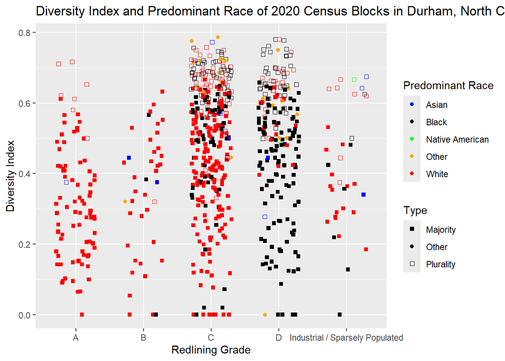

```r
combinedData2020 |>
  filter(blockType != "Industrial / Sparsely Populated") |>
  ggplot(aes(grade, diversity)) +
    geom_jitter(width = 0.3, aes(color = predomRace, shape=MajOrPlu)) +
    scale_shape_manual(name = "Type", values = c(15, 16, 0)) +
    scale_color_manual(name = "Predominant Race", values = c("blue", "black", "green", "orange", "red")) +
    ggtitle("Diversity Index and Predominant Race of 2020 Census Blocks in Durham, North Carolina, by Redlining Grade") +
    xlab("Redlining Grade") + ylab("Diversity Index")
```

These plots demonstrate that the diversity index in Durham increased significantly between 2000 and 2020, and particularly in C and D-graded blocks These plots also illustrate how strong of a predictor redlining grade was of predominant race in each block in 2000, and how this phenomenon has begun to erode (although not entirely) by 2020. Finally, it is worth noting the degree to which C-graded blocks in 2000, which were about evenly split between predominantly black and predominantly white, had become much whiter by 2020, while A and B-graded tracts remained heavily white between 2000 and 2020 and D-graded tracts remained heavily black.

#### Maps

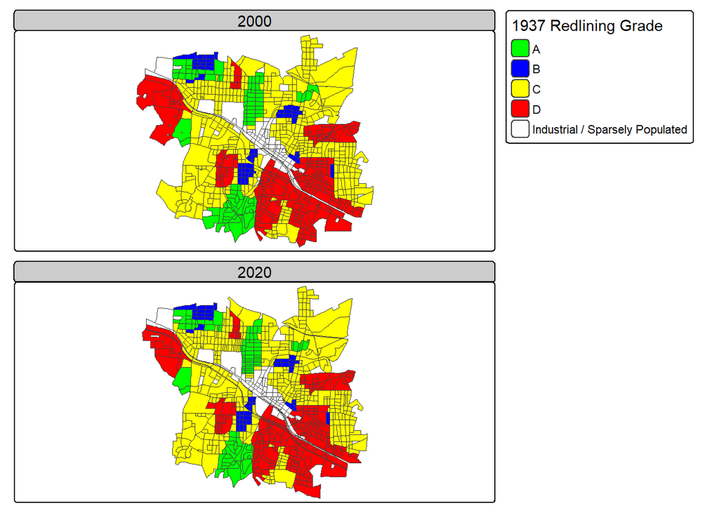

```r
tm_shape(combinedDataAll) + #grade
  tm_polygons("grade",
              fill.legend = tm_legend("1937 Redlining Grade"),
              fill.scale = tm_scale(
                values = c("green", "blue", "yellow", "red", "white"))
              ) +
  tm_facets_wrap("year", nrow = 2)
```

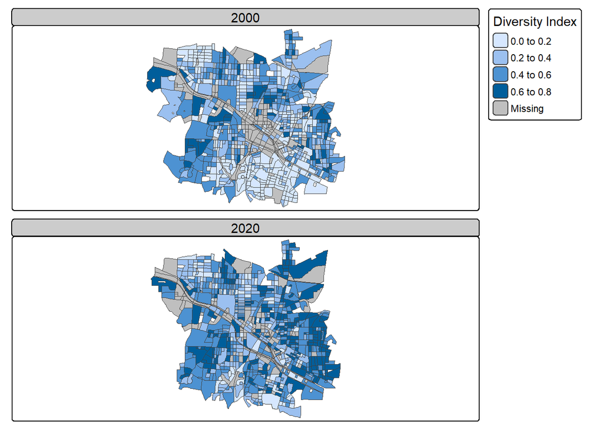

```r
tm_shape(combinedDataAll) + #diversity
  tm_polygons("diversity",
              fill.legend = tm_legend("Diversity Index"),
              fill.scale = tm_scale_intervals()
  ) +
  tm_facets_wrap("year", nrow = 2)
```

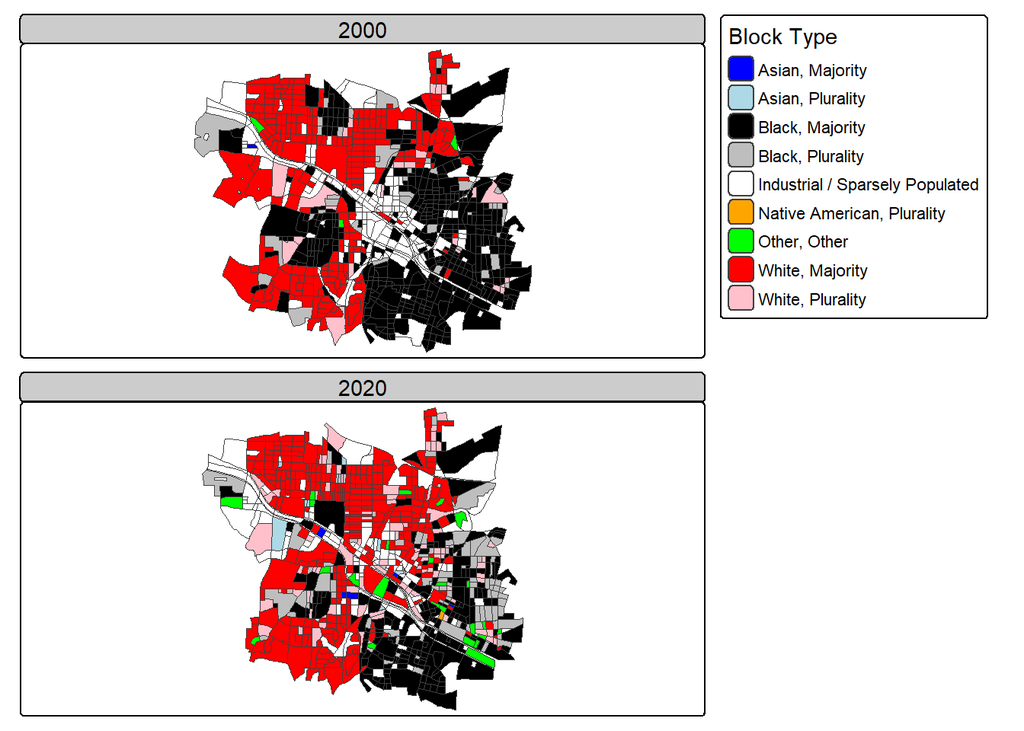

```r
tm_shape(combinedDataAll) + #predom race
  tm_polygons("blockType",
              fill.legend = tm_legend("Block Type"),
              fill.scale = tm_scale(
                values = c("blue", "lightblue", "black", "gray", "white", "orange", "green", "red", "pink"))
  ) +
  tm_facets_wrap("year", nrow = 2)
```

This series of maps illustrates further how redlining is related to blockwise trends in diversity and racial makeup. The first facet map demonstrates how the classification scheme is applied across 2000 and 2020 census blocks. The second facet map shows how diversity index has changed over time in different blocks across the city. Finally, the third map is colored according to the predominant racial group within each block for 2000 and 2020, and shaded according to whether the predominant racial group represents a majority or plurality within the block.

#### Statistical tests

```r
combinedDataAll |>
  as.data.frame() |>
  drop_na(diversity) |>
  group_by(year) |>
  summarize(
    `Number of Tracts` = n(),
    `Total Population` = sum(p_total),
    `Mean Diversity` = mean(diversity)
    )
```

```
## # A tibble: 2 × 4
##    year `Number of Tracts` `Total Population` `Mean Diversity`
##   <dbl>              <int>              <dbl>            <dbl>
## 1  2000                706              51769            0.293
## 2  2020                730              41895            0.462
```

While the population in the study area of central Durham shrunk by nearly 10,000 residents between 2000 and 2020, the the mean block diversity index increased by nearly 0.17.

```r
combinedDataAll |>
  as.data.frame() |>
  drop_na(diversity) |>
  group_by(grade) |>
  summarize(
    `Mean Diversity Index, 2000` = mean(diversity[year == 2000]),
    `Mean Diversity Index, 2020` = mean(diversity[year == 2020]),
    `% Change in Diversity Index, 2000-2020` = (mean(diversity[year == 2020])
                                               -mean(diversity[year == 2000]))
                                               /mean(diversity[year == 2000])
                                               *100
    )
```

```
## # A tibble: 5 × 4
##   grade     Mean Diversity Index…¹ Mean Diversity Index…² % Change in Diversit…³
##   <chr>                      <dbl>                  <dbl>                  <dbl>
## 1 A                          0.198                  0.324                   63.6
## 2 B                          0.268                  0.344                   28.1
## 3 C                          0.362                  0.499                   37.6
## 4 D                          0.223                  0.490                  119.
## 5 Industri…                  0.223                  0.414                   86.2
## # ℹ abbreviated names: ¹`Mean Diversity Index, 2000`,
## #   ²`Mean Diversity Index, 2020`, ³`% Change in Diversity Index, 2000-2020`
```

However, this increase in diversity was not even across blocks of differing redlining grades. Blocks graded “D” saw a 119% increase in diversity index between 2000 and 2020, while blocks graded “B” saw only a 28% increase in diversity index.

```r
#total pop change
combinedDataAll |>
  as.data.frame() |>
  drop_na(diversity) |>
  group_by(grade) |>
  summarize(
    `Total Population, 2000` = sum(p_total[year == 2000]),
    `Total Population, 2020` = sum(p_total[year == 2020]),
    `% change in Total Population, 2000-2020` = (sum(p_total[year == 2020])-
                                                sum(p_total[year == 2000]))/
                                                sum(p_total[year == 2000])*100
  )
```

```
## # A tibble: 5 × 4
##   grade     Total Population, 20…¹ Total Population, 20…² % change in Total Po…³
##   <chr>                      <dbl>                  <dbl>                  <dbl>
## 1 A                           4239                   3186                  -24.8
## 2 B                           1817                   1364                  -24.9
## 3 C                          23385                  20485                  -12.4
## 4 D                          19663                  11366                  -42.2
## 5 Industri…                   2665                   5494                  106.
## # ℹ abbreviated names: ¹`Total Population, 2000`, ²`Total Population, 2020`,
## #   ³`% change in Total Population, 2000-2020`
```

```r
#white pop change
combinedDataAll |>
  as.data.frame() |>
  drop_na(diversity) |>
  group_by(grade) |>
  summarize(
    `Total White Population, 2000` = sum(p_white[year == 2000]),
    `Total White Population, 2020` = sum(p_white[year == 2020]),
    `% change in White Population, 2000-2020` = (sum(p_white[year == 2020])-
                                                sum(p_white[year == 2000]))/
                                                sum(p_white[year == 2000])*100
  )
```

```
## # A tibble: 5 × 4
##   grade     Total White Populati…¹ Total White Populati…² % change in White Po…³
##   <chr>                      <dbl>                  <dbl>                  <dbl>
## 1 A                           3421                   2520                  -26.3
## 2 B                           1185                    972                  -18.0
## 3 C                           7408                   8925                   20.5
## 4 D                           3813                   2603                  -31.7
## 5 Industri…                   1542                   2668                   73.0
## # ℹ abbreviated names: ¹`Total White Population, 2000`,
## #   ²`Total White Population, 2020`, ³`% change in White Population, 2000-2020`
```

```r
#nonwhite pop change
combinedDataAll |>
  as.data.frame() |>
  mutate(p_nonWt = p_total - p_white) |>
  drop_na(diversity) |>
  group_by(grade) |>
  summarize(
    `Total Nonwhite Population, 2000` = sum(p_nonWt[year == 2000]),
    `Total Nonwhite Population, 2020` = sum(p_nonWt[year == 2020]),
    `% change in Nonwhite Population, 2000-2020` = (sum(p_nonWt[year == 2020])-
                                                sum(p_nonWt[year == 2000]))/
                                                sum(p_nonWt[year == 2000])*100
  )
```

```
## # A tibble: 5 × 4
##   grade     Total Nonwhite Popul…¹ Total Nonwhite Popul…² % change in Nonwhite…³
##   <chr>                      <dbl>                  <dbl>                  <dbl>
## 1 A                            818                    666                  -18.6
## 2 B                            632                    392                  -38.0
## 3 C                          15977                  11560                  -27.6
## 4 D                          15850                   8763                  -44.7
## 5 Industri…                   1123                   2826                  152.
## # ℹ abbreviated names: ¹`Total Nonwhite Population, 2000`,
## #   ²`Total Nonwhite Population, 2020`,
## #   ³`% change in Nonwhite Population, 2000-2020`
```

### Discussion

Further research could use data from additional time periods to obtain a greater understanding of the temporal aspect of demographic shifts in central Durham. Additionally, this methodology could be applied to other metropolitan areas to see if these findings are generalizable to the entire country.

### Citations

Fritz, M.J. (2025, March 7). Federal Housing Administration (FHA). Encyclopedia Britannica. https://www.britannica.com/topic/Federal-Housing-Administration

Gross, T. (2017, May 3). A “Forgotten History” Of How The U.S. Government Segregated America. *NPR*. https://www.npr.org/2017/05/03/526655831/a-forgotten-history-of-how-the-u-s-government-segregated-america

Kochhar, Rakesh, and Mohamad Moslimani. (2023, December 4). 4. The assets households own and the debts they carry. In *Wealth Surged in the Pandemic, but Debt Endures for Poorer Black and Hispanic Families*. Pew Research Center. https://www.pewresearch.org/2023/12/04/the-assets-households-own-and-the-debts-they-carry/